# Data Summarization and Transformation - 2

One should look for what is and not what he thinks should be. (Albert Einstein)

# Module completion checklist

| Topic | Complete |
| --- | --- |
| Transform messy data to tidy data using tidyr package |  |
| Manipulate columns by using the separate and unite functions |  |

# Using tidyr to tidy data

- Tidy data is defined by three main properties:
  - Each variable must have its own **column**
  - Each observation must have its own **row**
  - Each value must have its own **cell**
- Using the tidyr package can help us tidy our wrangled data
- The most important functions for restructuring rows and columns involve a `pivot`

# pivot_longer()

- `pivot_longer()` pulls multiple columns into one new variable

```r
?tidyr::pivot_longer

pivot_longer(cols,        #<- columns to convert
             names_to,    #<- name of new key column
             values_to)   #<- name of new value column
```

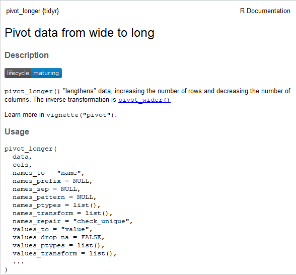

# pivot_longer parameters

We need three parameters for `pivot_longer()`:

- The set of columns that represent the values
- The name of the variable (which we decide upon) that represents those values, or the `key`
- The name of the variable (which we decide upon) that represents the values that are currently within the value columns, or the `value`

# pivot_longer example

- Let’s look at `table4a` data from the WHO tuberculosis dataset

```r
table4a
```

```
# A tibble: 3 x 3
  country     `1999` `2000`
* <chr>        <int>  <int>
1 Afghanistan    745   2666
2 Brazil       37737  80488
3 China       212258 213766
```

- Notice that the second and third column are actually both values (1999 and 2000) of a single hypothetical variable, year
- We can use pivot_longer to combine these two columns into a single column, year
- We can also create a new column, cases, to contain the count that currently appears in the 1999 and 2000 columns

# pivot_longer example contd

- Let’s pivot the `table4a` data frame from a wide format to a long format

```r
# Gather the `table4a` data frame to make it tidy.
table4a %>%    #<- set the data frame and use pipe to use it as input into `pivot_longer`
  pivot_longer(cols = `1999`:`2000`, #<- set columns to convert
               names_to = "year",    #<- set `year` column as a key
               values_to = "cases")  #<- set `cases` column for the values
```

```
# A tibble: 6 x 3
  country     year   cases
  <chr>       <chr>  <int>
1 Afghanistan 1999     745
2 Afghanistan 2000    2666
3 Brazil      1999   37737
4 Brazil      2000   80488
5 China       1999  212258
6 China       2000  213766
```

- Reminder: You can use the pipe (`%>%`) in all the packages within `tidyverse`!

# pivot_longer example specifying a range

- Let’s modify the same example, this time using the colon syntax to specify range
- Note that the code substitutes `2:3` instead of column names

```r
# Gather the `table4a` data frame to make it tidy.
table4a %>%    #<- set the data frame and use pipe to use it as input into `pivot_longer`
  pivot_longer(cols = 2:3,           #<- set columns to convert
               names_to = "year",    #<- set `year` column as a key
               values_to = "cases")  #<- set `cases` column for the values
```

```
# A tibble: 6 x 3
  country     year   cases
  <chr>       <chr>  <int>
1 Afghanistan 1999     745
2 Afghanistan 2000    2666
3 Brazil      1999   37737
4 Brazil      2000   80488
5 China       1999  212258
6 China       2000  213766
```

# pivot_wider()

- You use `pivot_wider()` when an observation is scattered across multiple rows
- `pivot_wider()` spreads one column into multiple variables
- `pivot_wider()` is the opposite of `pivot_longer()`

```r
?tidyr::pivot_wider()

pivot_wider(names_from,   #<- name of current key column
            values_from)  #<- name of current value column
```

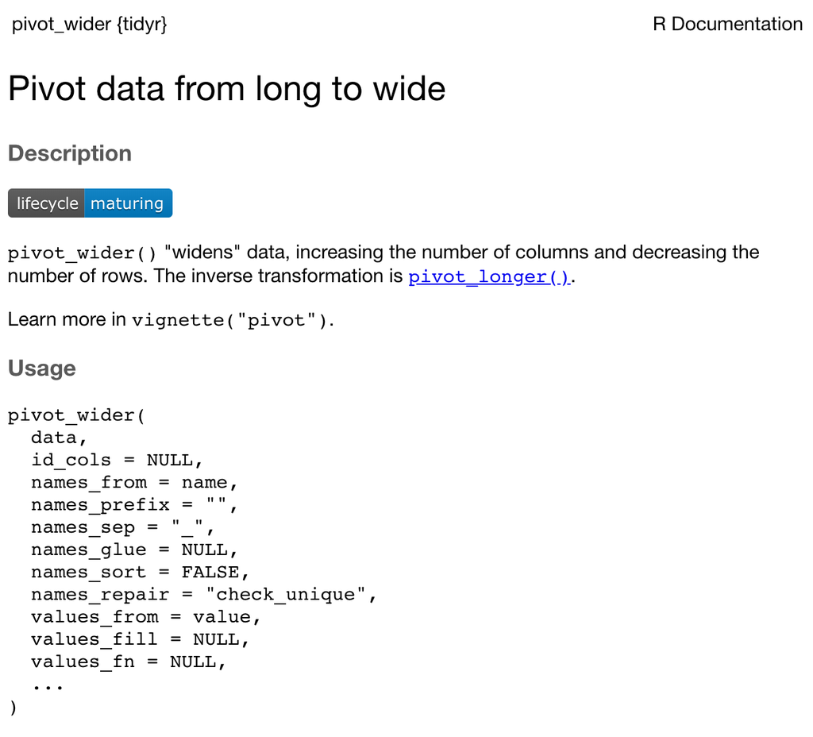

# pivot_wider parameters

There are two parameters we need to pay attention to when using `pivot_wider`:

- The column that contains the variable names, the `names_from` column
- The column that contains the values for the multiple variables, the `values_from` column

# pivot_wider example

- Use `table2` as the initial data frame
- The type column currently contains multiple categories of information, `cases` and `population`
- To reshape and tidy this table, we might create a `cases` column and a `population` column

```r
# Let's look at `table2` inbuilt data.
table2
```

```
# A tibble: 12 x 4
   country      year type            count
   <chr>       <int> <chr>           <int>
 1 Afghanistan  1999 cases             745
 2 Afghanistan  1999 population   19987071
 3 Afghanistan  2000 cases            2666
 4 Afghanistan  2000 population   20595360
 5 Brazil       1999 cases           37737
 6 Brazil       1999 population  172006362
 7 Brazil       2000 cases           80488
 8 Brazil       2000 population  174504898
 9 China        1999 cases          212258
10 China        1999 population 1272915272
11 China        2000 cases          213766
12 China        2000 population 1280428583
```

# pivot_wider example contd

- Let’s pivot the `table2` data frame from a long format to a wide format
- Use `pivot_wider()` with 2 main parameters:
  - The `type`, which contains the variables
  - The `count`, which contains the values for each of the rows of the variables in the `type` column

```r
# Spread the data
# Pass data to spread with pipe.
table2 %>%
  pivot_wider(names_from = type,
              values_from = count)
```

```
# A tibble: 6 x 4
  country      year  cases population
  <chr>       <int>  <int>      <int>
1 Afghanistan  1999    745   19987071
2 Afghanistan  2000   2666   20595360
3 Brazil       1999  37737  172006362
4 Brazil       2000  80488  174504898
5 China        1999 212258 1272915272
6 China        2000 213766 1280428583
```

# Module completion checklist

| Topic | Complete |
| --- | --- |
| Transform messy data to tidy data using tidyr package | **✔** |
| Manipulate columns by using the separate and unite functions |  |

# Separating and uniting

- We can also use **tidyr** to address a single variable, a single column, containing multiple pieces of information

```r
table3
```

```
# A tibble: 6 x 3
  country      year rate
* <chr>       <int> <chr>
1 Afghanistan  1999 745/19987071
2 Afghanistan  2000 2666/20595360
3 Brazil       1999 37737/172006362
4 Brazil       2000 80488/174504898
5 China        1999 212258/1272915272
6 China        2000 213766/1280428583
```

- For instance, `table3` shows both cases and population as a single rate
- We can use the function `separate()` to extract the values into separate columns
- We will also practice using the complementary function, `unite()`

# separate() parameters

- `separate()` separates a single character column into multiple columns and takes two arguments:
  - The column to be separated
  - What to separate the variable into, like into = c(“var_1”, “var_2”)

```r
?tidyr::separate

separate(df,   #<- data frame
         col,  #<- name of column to separate
         into) #<- name of new variables to
               #   create as a character vector
```

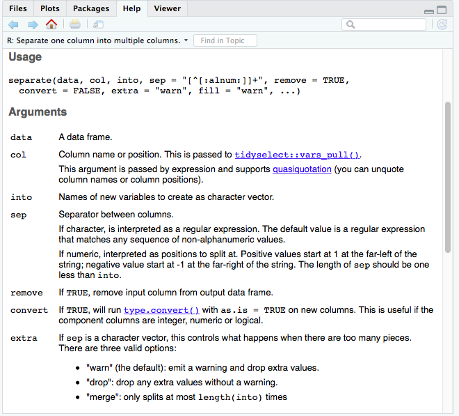

# separate example

- Let’s try out `separate()` on `table3` to create `cases` and `population` columns using the pipe operator

```r
# Using `table3` separate its `rate` column into two.
table3 %>%                   #<- set data frame and pass it to next function with pipe
  separate(rate,                   #<- separate `rate`
           into = c("cases",       #<- into column `cases`, and
                    "population")) #<-      column `population`
```

```
# A tibble: 6 x 4
  country      year cases  population
  <chr>       <int> <chr>  <chr>
1 Afghanistan  1999 745    19987071
2 Afghanistan  2000 2666   20595360
3 Brazil       1999 37737  172006362
4 Brazil       2000 80488  174504898
5 China        1999 212258 1272915272
6 China        2000 213766 1280428583
```

# separate example using `sep`

- By default, `separate()` will operate on any non alpha-numeric character
- However, it is also possible to specify the character by which to split using the `sep=` parameter

```r
# Using `table3` separate its `rate` column into two.
table3 %>%
  separate(rate,
           into = c("cases",
                    "population"),
           sep = "/")              #<- set the separating character to `/`
```

```
# A tibble: 6 x 4
  country      year cases  population
  <chr>       <int> <chr>  <chr>
1 Afghanistan  1999 745    19987071
2 Afghanistan  2000 2666   20595360
3 Brazil       1999 37737  172006362
4 Brazil       2000 80488  174504898
5 China        1999 212258 1272915272
6 China        2000 213766 1280428583
```

# separate example using `sep`

- Next, let’s use the `sep` parameter to separate the year column on the **character index**
- If we split the `year` column at index 2, we can create two new columns: `century` and `year`

```r
# Using `table3` separate its `year` column into two.
table3 %>%
  separate(year,              #<- separate `year`
           into= c("century", #<- into two columns: `century`, and
                   "year"),   #<-                   `year`
           sep = 2)           #<- set the separator at index = 2
```

```
# A tibble: 6 x 4
  country     century year  rate
  <chr>       <chr>   <chr> <chr>
1 Afghanistan 19      99    745/19987071
2 Afghanistan 20      00    2666/20595360
3 Brazil      19      99    37737/172006362
4 Brazil      20      00    80488/174504898
5 China       19      99    212258/1272915272
6 China       20      00    213766/1280428583
```

# Data type conversions using separate()

- When using `separate()`, the data type of the original column will be preserved

```r
# The new columns
# are now also characters.
table3 %>%
  separate(rate, into = c("cases", "population"))
```

```
# A tibble: 6 x 4
  country      year cases  population
  <chr>       <int> <chr>  <chr>
1 Afghanistan  1999 745    19987071
2 Afghanistan  2000 2666   20595360
3 Brazil       1999 37737  172006362
4 Brazil       2000 80488  174504898
5 China        1999 212258 1272915272
6 China        2000 213766 1280428583
```

- However, `separate()` can be instructed to convert to what it thinks the data types of new columns should be

```r
table3 %>%
  separate(rate, into = c("cases", "population"), convert = TRUE)
```

```
# A tibble: 6 x 4
  country      year  cases population
  <chr>       <int>  <int>      <int>
1 Afghanistan  1999    745   19987071
2 Afghanistan  2000   2666   20595360
3 Brazil       1999  37737  172006362
4 Brazil       2000  80488  174504898
5 China        1999 212258 1272915272
6 China        2000 213766 1280428583
```

# unite()

- `unite()` combines multiple character columns into a single column
- `unite()` is the inverse of separate

```r
?tidyr::unite

unite(df,  #<- data frame
      col, #<- name of column to unite
      sep) #<- separator to use
```

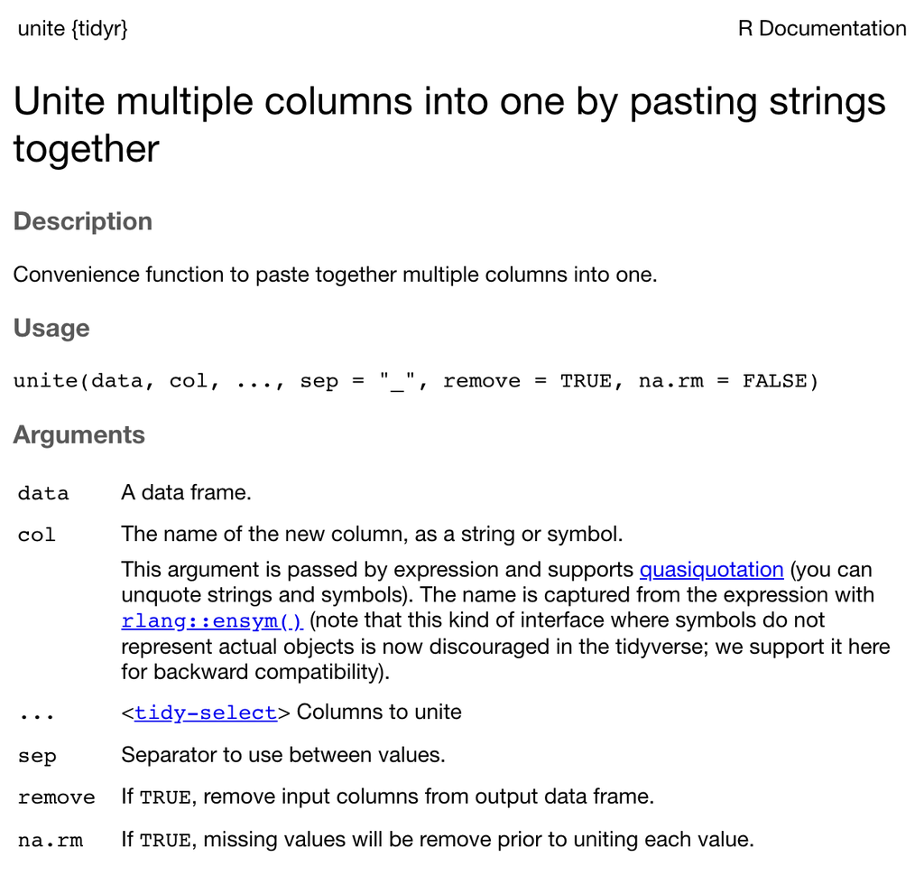

# unite parameters

# unite example

- To demonstrate how `unite()` works, let’s undo the separation of century and year in `table3`

```r
# Let's separate the `table3`'s `year` column into `century` and `year` first.
ex_table = table3 %>%
  separate(year, into = c("century", "year"), sep = 2)
ex_table
```

```
# A tibble: 6 x 4
  country     century year  rate
  <chr>       <chr>   <chr> <chr>
1 Afghanistan 19      99    745/19987071
2 Afghanistan 20      00    2666/20595360
3 Brazil      19      99    37737/172006362
4 Brazil      20      00    80488/174504898
5 China       19      99    212258/1272915272
6 China       20      00    213766/1280428583
```

```r
# Now we use `unite` to combine the two new columns back into one.
# By default, unite will combine columns using `_` so we can use `sep` to specify that we
# do not want anything between the two columns when combined into one cell.
ex_table %>%      #<- specify the data frame to pipe into `unite`
  unite(time,     #<- set the column `time` for combined values
        century,  #<- 1st column to unite
        year,     #<- 2nd column to unite
        sep = "") #<- set the separator to an empty string
```

```
# A tibble: 6 x 3
  country     time  rate
  <chr>       <chr> <chr>
1 Afghanistan 1999  745/19987071
2 Afghanistan 2000  2666/20595360
3 Brazil      1999  37737/172006362
4 Brazil      2000  80488/174504898
5 China       1999  212258/1272915272
6 China       2000  213766/1280428583
```

# Knowledge check

# Exercise

You are now ready to try Tasks 4-9 in the Exercise for this topic

# Module completion checklist

| Topic | Complete |
| --- | --- |
| Transform messy data to tidy data using tidyr package | **✔** |
| Manipulate columns by using the separate and unite functions | **✔** |

# Data Summarization and Transformation: Topic summary

In this part of the course, we have covered:

- Tidy data best practices
- Transform data with tidyr

# Congratulations on completing this module!